# (Simple) Linear Regression Model

Suppose that you have a pair of variables that you suspect have a linear relationship. That is, you have an **independent (input) variable** $x$ and a **dependent (response) variable** $Y$ such that $$Y = \alpha + \beta x + e$$ for some *unknown* real numbers $\alpha$ and $\beta$ and some **random error** $e$.

Given a set of observations $(x_1,Y_1),(x_2,Y_2),\dots,(x_n,Y_n)$, how can we use these data points to *best* estimate $\alpha$ and $\beta$? This is a **linear regression model**.

```python
import numpy as np
import matplotlib.pyplot as plt
import pandas as pd
```

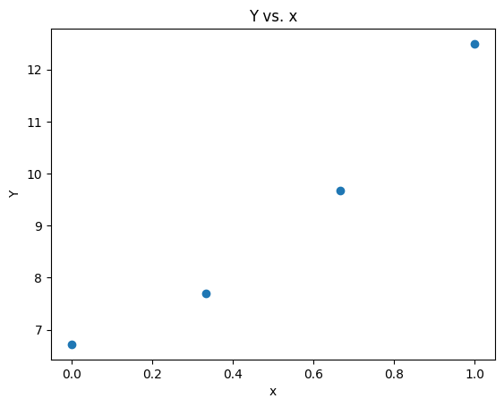

```python
x = np.array([0.0, 0.33333333, 0.66666667, 1.0])
Y = np.array([ 6.71999892,  7.69700969,  9.67335271, 12.49282965])
plt.scatter(x,Y)
plt.xlabel('x')
plt.ylabel('Y')
plt.title('Y vs. x')
plt.show()
```

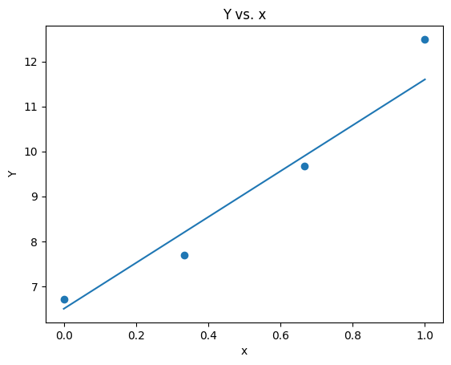

```python
Y2 = 5.1*x + 6.5
plt.scatter(x,Y)
plt.plot(x, Y2,color='#1f77b4')
plt.xlabel('x')
plt.ylabel('Y')
plt.title('Y vs. x')
plt.show()
```

What do we mean by *best*? Is there a single answer?

# Estimating the Regression Parameters

Suppose that we pick a linear model $$Y = A + Bx$$ with $A$ and $B$ as our guesses for the values of $\alpha$ and $\beta$, respectively. Let $$\epsilon_i = Y_i - A - Bx_i$$ for $i=1,2,\dots,n$. The $\epsilon_i$ values represent the errors from using estimators $A$ and $B$.

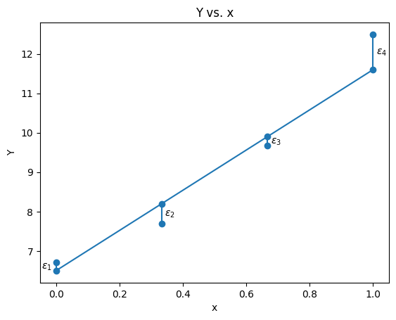

```python
plt.scatter(x,Y)
plt.scatter(x, Y2,color='#1f77b4')
plt.plot(x, Y2,color='#1f77b4')
for i in range(4):
    plt.plot([x[i],x[i]],[Y2[i],Y[i]],color='#1f77b4')
    plt.text(x[i]+0.01*(i>0)-0.045*(i==0),abs(Y[i]+Y2[i])/2-0.06,f'$\epsilon_{i+1}$')
plt.xlabel('x')
plt.ylabel('Y')
plt.title('Y vs. x')
plt.show()
```

We want to minimize the error by minimizing $$\sum_{i=1}^n \epsilon_i^2 = \sum_{i=1}^n(Y_i - A - Bx_i)^2.$$ This is the sum of squares of the errors.

The **least-squares estimators** of $\alpha$ and $\beta$ are given by $$\hat{\beta} = \frac{\sum_{i=1}^n(x_i-\overline{x})(Y_i-\overline{Y})}{\sum_{i=1}^n(x_i-\overline{x})^2}$$ and $$\hat{\alpha} = \overline{Y} - \hat{\beta}\overline{x},$$ where $$\overline{x}=\frac{1}{n}\sum_{i=1}^n x_i\text{ and }\overline{Y}=\frac{1}{n}\sum_{i=1}^n Y_i.$$

# Using Scikit-Learn (very fancy)

```python
from sklearn.linear_model import LinearRegression
from sklearn.metrics import mean_squared_error

linear = LinearRegression()
linear.fit(x.reshape(-1,1),Y)
print(f'We estimate beta by {linear.coef_[0].round(2)} and alpha by {linear.intercept_.round(2)}.')
err = float(mean_squared_error(linear.predict(x.reshape(-1,1)),Y))
print(f'The least-squared error is given by {round(err,3)}.')
```

```
We estimate beta by 5.79 and alpha by 6.25.
The least-squared error is given by 0.212.
```

# Less fancy

```python
x_bar = x.mean()
Y_bar = Y.mean()
top = sum([(x[i]-x_bar)*(Y[i]-Y_bar) for i in range(4)])
bottom = sum([(x[i]-x_bar)**2 for i in range(4)])
beta = top/bottom
alpha = Y_bar - beta*x_bar
print(f'We estimate beta by {round(beta,2)} and alpha by {round(alpha,2)}.')
err = sum([(Y[i] - (alpha + beta*x[i]))**2 for i in range(4)])
print(f'The least-squared error is given by {round(err,3)}.')
```

```
We estimate beta by 5.79 and alpha by 6.25.
The least-squared error is given by 0.85.
```

# Plot of the least-squares estimator

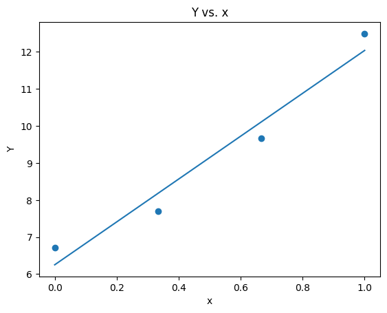

```python
Y3 = linear.coef_[0]*x + linear.intercept_
plt.scatter(x,Y)
plt.plot(x, Y3,color='#1f77b4')
plt.xlabel('x')
plt.ylabel('Y')
plt.title('Y vs. x')
plt.show()
```

# Coefficient of Determination

The simplest linear model that we could use to model our data would be a horizontal line with the height given by $\overline{Y}$. So how much better is the least-squares regression model compared to this baseline?

Let $$S_{YY} = \sum_{i=1}^n (Y_i - \overline{Y})^2$$ be the sum of squares of the deviations of $Y$ and let $$S_R = \sum_{i=1}^n (Y_i - \hat{\alpha}- \hat{\beta}x_i)^2$$ be the error from our model.

We define the **coefficient of determination** as $$R^2 = 1 - \frac{S_R}{S_{YY}}.$$ Note that $0\leq R^2\leq 1$.

When $R^2$ is close to $1$, it means that $S_R$ is much smaller than $S_{YY}$, suggesting that our model is a very good fit. If $R^2$ is close to $0$, it means that our model is not much better than just predicting everything as the mean $\overline{Y}$.

# Using Scikit-Learn (very fancy)

```python
from sklearn.metrics import r2_score

r2 = float(r2_score(linear.predict(x.reshape(-1,1)),Y))
print(f'The coefficient of determination is given by {round(r2,3)}.')
```

```
The coefficient of determination is given by 0.954.
```

# Less fancy

```python
S_r = err
S_YY = sum([(Y[i]-Y_bar)**2 for i in range(4)])
r2 = 1 - S_r/S_YY
print(f'The coefficient of determination is given by {round(r2,3)}.')
```

```
The coefficient of determination is given by 0.956.
```